# R_Homework

# Data Proccessing

- First, separate out the groups of interest we want for maize (ZMMIL, ZMMLR, and ZMMMR) and teosinte (ZMPBA, ZMPIL, and ZMPJA) from `fang_et_al_genotypes.txt`:

```r
library(dplyr)
```

**maize:**

```r
genotypes_by_groups_maize <- filter(genotype_data_raw, Group == "ZMMIL" | Group == "ZMMLR" | Group == "ZMMMR")

head(genotypes_by_groups_maize)
```

```
##   Sample_ID                 JG_OTU Group abph1.20 abph1.22 ae1.3 ae1.4
## 1 ZDP_0752a Zmm-LR-ACOM-usa-NM-1_s ZMMLR      C/G      A/A   T/T   G/G
## 2 ZDP_0793a   Zmm-LR-ACOM-usa-NM-2 ZMMLR      C/G      A/A   T/T   G/G
## 3 ZDP_0612a   Zmm-LR-ALAZ-Per-JEQU ZMMLR      C/C      A/A   T/T   G/G
## 4 ZDP_0602a   Zmm-LR-ALAZ-Per-MOCH ZMMLR      C/G      A/A   G/T   A/G
## 5 ZDP_0581a   Zmm-LR-ALAZ-Per-PICS ZMMLR      C/C      A/A   T/T   G/G
## 6 ZDP_0552a   Zmm-LR-ALAZ-Per-VIRU ZMMLR      C/G      A/A   T/T   G/G
##   ae1.5 an1.4 ba1.6 ba1.9 bt2.5 bt2.7 bt2.8 Fea2.1 Fea2.5 id1.3 lg2.11
## 1   C/C   C/G   G/G   G/G   C/C   ?/?   A/A    C/G    A/A   C/T    C/C
## 2   C/T   C/G   A/G   G/T   C/C   ?/?   A/A    C/G    A/A   C/T    C/C
## 3   C/C   C/C   G/G   ?/?   C/C   G/G   A/A    C/G    A/G   C/C    C/C
## 4   C/T   C/C   G/G   G/G   C/C   G/G   A/A    C/G    A/G   C/C    C/C
## 5   C/T   C/C   G/G   G/G   C/C   G/G   A/A    C/C    G/G   C/T    C/C
## 6   C/T   C/C   G/G   G/G   C/C   G/G   A/A    C/G    A/G   C/C    C/T
##   lg2.2 pbf1.1 pbf1.2 pbf1.3 pbf1.5 pbf1.6 pbf1.7 pbf1.8 PZA00003.11
```

[output cut: 1119 more lines]

**teosinte:**

```r
genotypes_by_groups_teosinte <- filter(genotype_data_raw, Group == "ZMPBA" | Group == "ZMPIL" | Group == "ZMPJA")

head(genotypes_by_groups_teosinte)
```

```
##   Sample_ID             JG_OTU Group abph1.20 abph1.22 ae1.3 ae1.4 ae1.5
## 1     S0881 Zmp-B-ACAPET-GR-01 ZMPBA      C/G      A/A   T/T   G/G   T/T
## 2     S1057 Zmp-B-ACAPET-GR-02 ZMPBA      C/G      A/A   G/T   A/G   T/T
## 3     S1087 Zmp-B-ACAPET-GR-03 ZMPBA      G/G      A/A   T/T   G/G   T/T
## 4     S1689 Zmp-B-ACAPET-GR-04 ZMPBA      G/G      A/A   T/T   G/G   T/T
## 5     S1697 Zmp-B-ACAPET-GR-05 ZMPBA      C/G      A/A   T/T   G/G   T/T
## 6     S1698 Zmp-B-ACAPET-GR-06 ZMPBA      C/G      A/A   T/T   A/G   T/T
##   an1.4 ba1.6 ba1.9 bt2.5 bt2.7 bt2.8 Fea2.1 Fea2.5 id1.3 lg2.11 lg2.2
## 1   C/C   A/G   G/G   T/T   A/A   G/G    G/G    A/A   C/C    C/C   A/G
## 2   C/C   A/A   G/G   C/T   A/A   ?/?    C/G    A/G   C/C    C/C   A/A
## 3   C/C   A/A   G/G   C/T   A/A   A/G    C/C    A/G   T/T    C/C   A/A
## 4   C/C   A/A   G/G   C/C   A/A   A/A    ?/?    A/A   C/T    C/C   A/A
## 5   C/C   A/A   G/G   C/C   A/A   A/A    C/G    A/G   C/C    C/C   A/G
## 6   C/C   A/A   G/G   C/T   A/A   A/G    G/G    A/A   C/C    C/C   A/A
##   pbf1.1 pbf1.2 pbf1.3 pbf1.5 pbf1.6 pbf1.7 pbf1.8 PZA00003.11 PZA00004.2
```

[output cut: 1119 more lines]

- Transpose data for both maize and teosinte:

**maize:**

```r
genotypes_maize_transposed <- t(genotypes_by_groups_maize)

head(genotypes_maize_transposed)
```

```
##           [,1]                     [,2]
## Sample_ID "ZDP_0752a"              "ZDP_0793a"
## JG_OTU    "Zmm-LR-ACOM-usa-NM-1_s" "Zmm-LR-ACOM-usa-NM-2"
## Group     "ZMMLR"                  "ZMMLR"
## abph1.20  "C/G"                    "C/G"
## abph1.22  "A/A"                    "A/A"
## ae1.3     "T/T"                    "T/T"
##           [,3]                   [,4]
## Sample_ID "ZDP_0612a"            "ZDP_0602a"
## JG_OTU    "Zmm-LR-ALAZ-Per-JEQU" "Zmm-LR-ALAZ-Per-MOCH"
## Group     "ZMMLR"                "ZMMLR"
## abph1.20  "C/C"                  "C/G"
## abph1.22  "A/A"                  "A/A"
## ae1.3     "T/T"                  "G/T"
##           [,5]                   [,6]
## Sample_ID "ZDP_0581a"            "ZDP_0552a"
## JG_OTU    "Zmm-LR-ALAZ-Per-PICS" "Zmm-LR-ALAZ-Per-VIRU"
## Group     "ZMMLR"                "ZMMLR"
## abph1.20  "C/C"                  "C/G"
## abph1.22  "A/A"                  "A/A"
## ae1.3     "T/T"                  "T/T"
##           [,7]                   [,8]
## Sample_ID "ZDP_0543a"            "ZDP_0042a"
## JG_OTU    "Zmm-LR-ALEM-Per-TING" "Zmm-LR-ALTI-Arg-HUMA"
## Group     "ZMMLR"                "ZMMLR"
## abph1.20  "C/C"                  "C/C"
## abph1.22  "A/A"                  "A/A"
## ae1.3     "T/T"                  "T/T"
##           [,9]                   [,10]
## Sample_ID "ZDP_0121a"            "ZDP_0101b"
## JG_OTU    "Zmm-LR-ALTI-Bol-CHUQ" "Zmm-LR-ALTI-Bol-LAPA"
## Group     "ZMMLR"                "ZMMLR"
## abph1.20  "C/C"                  "C/C"
## abph1.22  "A/A"                  "A/A"
## ae1.3     "T/T"                  "G/T"
##           [,11]                  [,12]
## Sample_ID "ZDP_0087a"            "ZDP_0033a"
## JG_OTU    "Zmm-LR-ALTI-Bol-TACA" "Zmm-LR-AMAG-Col-ANGO"
## Group     "ZMMLR"                "ZMMLR"
## abph1.20  "?/?"                  "C/G"
```

[output cut: 4726 more lines]

```
## ae1.3     "T/T"          "T/T"                  "T/T"
##           [,1569]         [,1570]           [,1571]       [,1572]
## Sample_ID "S0398"         "S1636"           "CU0201"      "S0215"
## JG_OTU    "Zmm-IL-W64A_a" "Zmm-IL-W64A_b_s" "Zmm-IL-WD_f" "Zmm-IL-Wf9"
## Group     "ZMMIL"         "ZMMIL"           "ZMMIL"       "ZMMIL"
## abph1.20  "G/G"           "G/G"             "C/C"         "G/G"
## abph1.22  "A/A"           "A/A"             "A/A"         "A/A"
## ae1.3     "T/T"           "T/T"             "T/T"         "T/T"
##           [,1573]
## Sample_ID "CU0202"
## JG_OTU    "Zmm-IL-Yu796_NS_f"
## Group     "ZMMIL"
## abph1.20  "C/C"
## abph1.22  "A/A"
## ae1.3     "T/T"
```

**teosinte:**

```r
genotypes_teosinte_transposed <- t(genotypes_by_groups_teosinte)

head(genotypes_teosinte_transposed)
```

```
##           [,1]                 [,2]                 [,3]
## Sample_ID "S0881"              "S1057"              "S1087"
## JG_OTU    "Zmp-B-ACAPET-GR-01" "Zmp-B-ACAPET-GR-02" "Zmp-B-ACAPET-GR-03"
## Group     "ZMPBA"              "ZMPBA"              "ZMPBA"
## abph1.20  "C/G"                "C/G"                "G/G"
## abph1.22  "A/A"                "A/A"                "A/A"
## ae1.3     "T/T"                "G/T"                "T/T"
##           [,4]                 [,5]                 [,6]
## Sample_ID "S1689"              "S1697"              "S1698"
## JG_OTU    "Zmp-B-ACAPET-GR-04" "Zmp-B-ACAPET-GR-05" "Zmp-B-ACAPET-GR-06"
## Group     "ZMPBA"              "ZMPBA"              "ZMPBA"
## abph1.20  "G/G"                "C/G"                "C/G"
## abph1.22  "A/A"                "A/A"                "A/A"
## ae1.3     "T/T"                "T/T"                "T/T"
##           [,7]                 [,8]                 [,9]
## Sample_ID "S1703"              "S1704"              "TA057"
## JG_OTU    "Zmp-B-ACAPET-GR-07" "Zmp-B-ACAPET-GR-08" "Zmp-B-ACAPET-GR-09_s"
## Group     "ZMPBA"              "ZMPBA"              "ZMPBA"
## abph1.20  "G/G"                "G/G"                "G/G"
## abph1.22  "A/A"                "A/A"                "A/A"
## ae1.3     "T/T"                "T/T"                "T/T"
##           [,10]                  [,11]
## Sample_ID "TA137"                "TA153"
## JG_OTU    "Zmp-B-ACAPET-GR-10_s" "Zmp-B-ACAPET-GR-11_s"
## Group     "ZMPBA"                "ZMPBA"
## abph1.20  "G/G"                  "G/G"
## abph1.22  "A/A"                  "A/A"
## ae1.3     "T/T"                  "T/T"
##           [,12]                  [,13]
## Sample_ID "TA205"                "TA217"
## JG_OTU    "Zmp-B-ACAPET-GR-12_s" "Zmp-B-ACAPET-GR-13_s"
## Group     "ZMPBA"                "ZMPBA"
## abph1.20  "C/G"                  "G/G"
## abph1.22  "A/A"                  "A/A"
## ae1.3     "T/T"                  "T/T"
##           [,14]                  [,15]
## Sample_ID "TA242"                "TA285"
## JG_OTU    "Zmp-B-ACAPET-GR-14_s" "Zmp-B-ACAPET-GR-15_s"
## Group     "ZMPBA"                "ZMPBA"
## abph1.20  "G/G"                  "G/G"
```

[output cut: 3305 more lines]

```
## ae1.3     "G/G"                     "G/G"
##           [,973]                    [,974]
## Sample_ID "TIP-272A"                "TIP-356-A"
## JG_OTU    "Zmp-TIL17-S4-B-ACAPET_v" "Zmp-TIL17-S5-B-ACAPET"
## Group     "ZMPIL"                   "ZMPIL"
## abph1.20  "G/G"                     "G/G"
## abph1.22  "A/A"                     "A/A"
## ae1.3     "T/T"                     "T/T"
##           [,975]
## Sample_ID "TIP-512"
## JG_OTU    "Zmp-TIL17-S7-B-ACAPET_s"
## Group     "ZMPIL"
## abph1.20  "G/G"
## abph1.22  "A/A"
## ae1.3     "T/T"
```

- Only need certain columns from the `snp_position.txt` file for the analysis so we can cut those out by using the `select` function in dplyr:

```r
snp_columns_needed <- select(snp_position_data_raw, SNP_ID, Chromosome, Position)

head(snp_columns_needed)
```

```
##     SNP_ID Chromosome  Position
## 1 abph1.20          2  27403404
## 2 abph1.22          2  27403892
## 3    ae1.3          5 167889790
## 4    ae1.4          5 167889682
## 5    ae1.5          5 167889821
## 6    an1.4          1 240498509
```

- Rename row names in `snp_position.txt`:

```r
rownames(snp_columns_needed) <- snp_columns_needed$SNP_ID
```

- Now we need to join the `snp_position.txt` with each of the maize group transposed and teosinte group transposed data files:

**maize:**

```r
joined_maize_genotypes_snp <- merge(snp_columns_needed, genotypes_maize_transposed, by ="row.names", all = FALSE)

joined_maize_genotypes_snp <- subset(joined_maize_genotypes_snp, select = -c(2,5:15))
```

**teosinte:**

```r
joined_teosinte_genotypes_snp <- merge(snp_columns_needed, genotypes_teosinte_transposed, by = "row.names", all = FALSE)

joined_teosinte_genotypes_snp <- subset(joined_teosinte_genotypes_snp, select = -c(2,5:15))
```

- For all **maize** files that are chromosome specific (chromosome 1-10), with **acending** chromosome position values, and have missing data encoded by a **?** :

**maize** chromomsome 1:

```r
chromosome1_maize_genotypes_snp <- filter(joined_maize_genotypes_snp, Chromosome == 1)

chromosome1_maize_genotypes_snp_arrange_ascending <- arrange(chromosome1_maize_genotypes_snp, Position)

write.csv(chromosome1_maize_genotypes_snp_arrange_ascending, "~/Desktop/BCB546_Assignments/R_Assignment/Final_files/maize_chr_ascend_question/chr1_maize_ascending_question.csv", row.names=F)
```

**maize** chromosome 2:

```r
chromosome2_maize_genotypes_snp <- filter(joined_maize_genotypes_snp, Chromosome == 2)

chromosome2_maize_genotypes_snp_arrange_ascending <- arrange(chromosome2_maize_genotypes_snp, Position)

write.csv(chromosome2_maize_genotypes_snp_arrange_ascending, "~/Desktop/BCB546_Assignments/R_Assignment/Final_files/maize_chr_ascend_question/chr2_maize_ascending_question.csv", row.names=F)
```

**maize** chromosome 3:

```r
chromosome3_maize_genotypes_snp <- filter(joined_maize_genotypes_snp, Chromosome == 3)

chromosome3_maize_genotypes_snp_arrange_ascending <- arrange(chromosome3_maize_genotypes_snp, Position)

write.csv(chromosome3_maize_genotypes_snp_arrange_ascending, "~/Desktop/BCB546_Assignments/R_Assignment/Final_files/maize_chr_ascend_question/chr3_maize_ascending_question.csv", row.names=F)
```

```r
chromosome4_maize_genotypes_snp <- filter(joined_maize_genotypes_snp, Chromosome == 4)

chromosome4_maize_genotypes_snp_arrange_ascending <- arrange(chromosome2_maize_genotypes_snp, Position)

write.csv(chromosome4_maize_genotypes_snp_arrange_ascending, "~/Desktop/BCB546_Assignments/R_Assignment/Final_files/maize_chr_ascend_question/chr4_maize_ascending_question.csv", row.names=F)
```

**maize** chromosome 5:

```r
chromosome5_maize_genotypes_snp <- filter(joined_maize_genotypes_snp, Chromosome == 5)

chromosome5_maize_genotypes_snp_arrange_ascending <- arrange(chromosome5_maize_genotypes_snp, Position)

write.csv(chromosome5_maize_genotypes_snp_arrange_ascending, "~/Desktop/BCB546_Assignments/R_Assignment/Final_files/maize_chr_ascend_question/chr5_maize_ascending_question.csv", row.names=F)
```

**maize** chromosome 6:

```r
chromosome6_maize_genotypes_snp <- filter(joined_maize_genotypes_snp, Chromosome == 6)

chromosome6_maize_genotypes_snp_arrange_ascending <- arrange(chromosome6_maize_genotypes_snp, Position)

write.csv(chromosome6_maize_genotypes_snp_arrange_ascending, "~/Desktop/BCB546_Assignments/R_Assignment/Final_files/maize_chr_ascend_question/chr6_maize_ascending_question.csv", row.names=F)
```

**maize** chromosome 7:

```r
chromosome7_maize_genotypes_snp <- filter(joined_maize_genotypes_snp, Chromosome == 7)

chromosome7_maize_genotypes_snp_arrange_ascending <- arrange(chromosome7_maize_genotypes_snp, Position)

write.csv(chromosome7_maize_genotypes_snp_arrange_ascending, "~/Desktop/BCB546_Assignments/R_Assignment/Final_files/maize_chr_ascend_question/chr7_maize_ascending_question.csv", row.names=F)
```

**maize** chromosome 8:

```r
chromosome8_maize_genotypes_snp <- filter(joined_maize_genotypes_snp, Chromosome == 8)

chromosome8_maize_genotypes_snp_arrange_ascending <- arrange(chromosome8_maize_genotypes_snp, Position)

write.csv(chromosome8_maize_genotypes_snp_arrange_ascending, "~/Desktop/BCB546_Assignments/R_Assignment/Final_files/maize_chr_ascend_question/chr8_maize_ascending_question.csv", row.names=F)
```

**maize** chromosome 9:

```r
chromosome9_maize_genotypes_snp <- filter(joined_maize_genotypes_snp, Chromosome == 9)

chromosome9_maize_genotypes_snp_arrange_ascending <- arrange(chromosome9_maize_genotypes_snp, Position)

write.csv(chromosome9_maize_genotypes_snp_arrange_ascending, "~/Desktop/BCB546_Assignments/R_Assignment/Final_files/maize_chr_ascend_question/chr9_maize_ascending_question.csv", row.names=F)
```

**maize** chromosome 10:

```r
chromosome10_maize_genotypes_snp <- filter(joined_maize_genotypes_snp, Chromosome == 10)

chromosome10_maize_genotypes_snp_arrange_ascending <- arrange(chromosome10_maize_genotypes_snp, Position)

write.csv(chromosome10_maize_genotypes_snp_arrange_ascending, "~/Desktop/BCB546_Assignments/R_Assignment/Final_files/maize_chr_ascend_question/chr10_maize_ascending_question.csv", row.names=F)
```

- For all **teosinte** files that are chromosome specific (chromosome 1-10), with **acending** chromosome position values, and have missing data encoded by a **?** :

**teosinte** chromosome 1:

```r
chromosome1_teosinte_genotypes_snp <- filter(joined_teosinte_genotypes_snp, Chromosome == 1)

chromosome1_teosinte_genotypes_snp_arrange_ascending <- arrange(chromosome1_teosinte_genotypes_snp, Position)

write.csv(chromosome1_teosinte_genotypes_snp_arrange_ascending, "~/Desktop/BCB546_Assignments/R_Assignment/Final_files/teosinte_chr_ascend_question/chr1_teosinte_ascending_question.csv", row.names=F)
```

**teosinte** chromosome 2:

```r
chromosome2_teosinte_genotypes_snp<- filter(joined_teosinte_genotypes_snp, Chromosome == 2)

chromosome2_teosinte_genotypes_snp_arrange_ascending <- arrange(chromosome2_teosinte_genotypes_snp, Position)

write.csv(chromosome2_teosinte_genotypes_snp_arrange_ascending, "~/Desktop/BCB546_Assignments/R_Assignment/Final_files/teosinte_chr_ascend_question/chr2_teosinte_ascending_question.csv", row.names=F)
```

**teosinte** chromosome 3:

```r
chromosome3_teosinte_genotypes_snp<- filter(joined_teosinte_genotypes_snp, Chromosome == 3)

chromosome3_teosinte_genotypes_snp_arrange_ascending <- arrange(chromosome3_teosinte_genotypes_snp, Position)

write.csv(chromosome3_teosinte_genotypes_snp_arrange_ascending, "~/Desktop/BCB546_Assignments/R_Assignment/Final_files/teosinte_chr_ascend_question/chr3_teosinte_ascending_question.csv", row.names=F)
```

**teosinte** chromosome 4:

```r
chromosome4_teosinte_genotypes_snp<- filter(joined_teosinte_genotypes_snp, Chromosome == 4)

chromosome4_teosinte_genotypes_snp_arrange_ascending <- arrange(chromosome4_teosinte_genotypes_snp, Position)

write.csv(chromosome4_teosinte_genotypes_snp_arrange_ascending, "~/Desktop/BCB546_Assignments/R_Assignment/Final_files/teosinte_chr_ascend_question/chr4_teosinte_ascending_question.csv", row.names=F)
```

**teosinte** chromosome 5:

```r
chromosome5_teosinte_genotypes_snp<- filter(joined_teosinte_genotypes_snp, Chromosome == 5)

chromosome5_teosinte_genotypes_snp_arrange_ascending <- arrange(chromosome5_teosinte_genotypes_snp, Position)

write.csv(chromosome5_teosinte_genotypes_snp_arrange_ascending, "~/Desktop/BCB546_Assignments/R_Assignment/Final_files/teosinte_chr_ascend_question/chr5_teosinte_ascending_question.csv", row.names=F)
```

**teosinte** chromosome 6:

```r
chromosome6_teosinte_genotypes_snp<- filter(joined_teosinte_genotypes_snp, Chromosome == 6)

chromosome6_teosinte_genotypes_snp_arrange_ascending <- arrange(chromosome6_teosinte_genotypes_snp, Position)

write.csv(chromosome6_teosinte_genotypes_snp_arrange_ascending, "~/Desktop/BCB546_Assignments/R_Assignment/Final_files/teosinte_chr_ascend_question/chr6_teosinte_ascending_question.csv", row.names=F)
```

**teosinte** chromosome 7:

```r
chromosome7_teosinte_genotypes_snp<- filter(joined_teosinte_genotypes_snp, Chromosome == 7)

chromosome7_teosinte_genotypes_snp_arrange_ascending <- arrange(chromosome7_teosinte_genotypes_snp, Position)

write.csv(chromosome7_teosinte_genotypes_snp_arrange_ascending, "~/Desktop/BCB546_Assignments/R_Assignment/Final_files/teosinte_chr_ascend_question/chr7_teosinte_ascending_question.csv", row.names=F)
```

**teosinte** chromosome 8:

```r
chromosome8_teosinte_genotypes_snp<- filter(joined_teosinte_genotypes_snp, Chromosome == 8)

chromosome8_teosinte_genotypes_snp_arrange_ascending <- arrange(chromosome8_teosinte_genotypes_snp, Position)

write.csv(chromosome8_teosinte_genotypes_snp_arrange_ascending, "~/Desktop/BCB546_Assignments/R_Assignment/Final_files/teosinte_chr_ascend_question/chr8_teosinte_ascending_question.csv", row.names=F)
```

**teosinte** chromosome 9:

```r
chromosome9_teosinte_genotypes_snp<- filter(joined_teosinte_genotypes_snp, Chromosome == 9)

chromosome9_teosinte_genotypes_snp_arrange_ascending <- arrange(chromosome9_teosinte_genotypes_snp, Position)

write.csv(chromosome9_teosinte_genotypes_snp_arrange_ascending, "~/Desktop/BCB546_Assignments/R_Assignment/Final_files/teosinte_chr_ascend_question/chr9_teosinte_ascending_question.csv", row.names=F)
```

**teosinte** chromosome 10:

```r
chromosome10_teosinte_genotypes_snp<- filter(joined_teosinte_genotypes_snp, Chromosome == 10)

chromosome10_teosinte_genotypes_snp_arrange_ascending <- arrange(chromosome10_teosinte_genotypes_snp, Position)

write.csv(chromosome10_teosinte_genotypes_snp_arrange_ascending, "~/Desktop/BCB546_Assignments/R_Assignment/Final_files/teosinte_chr_ascend_question/chr10_teosinte_ascending_question.csv", row.names=F)
```

For all the **maize** files that are chromosome specific (chromosome 1-10), with **decending** chromosome position values, and missing data encoded by a **-** :

**maize** chromosome 1:

```r
chromosome1_maize_genotypes_snp_arrange_descending <- arrange(chromosome1_maize_genotypes_snp, desc(Position))

chromosome1_maize_decending_dash <- as.data.frame(lapply(chromosome1_maize_genotypes_snp_arrange_descending, FUN = function(x)as.character(gsub("\\?", "-", x))))

write.csv(chromosome1_maize_decending_dash, "~/Desktop/BCB546_Assignments/R_Assignment/Final_files/maize_chr_decend_dash/chr1_maize_decending_dash.csv", row.names=F)
```

**maize** chromosome 2:

```r
chromosome2_maize_genotypes_snp_arrange_descending <- arrange(chromosome2_maize_genotypes_snp, desc(Position))

chromosome2_maize_decending_dash <- as.data.frame(lapply(chromosome2_maize_genotypes_snp_arrange_descending, FUN = function(x)as.character(gsub("\\?", "-", x))))

write.csv(chromosome2_maize_decending_dash, "~/Desktop/BCB546_Assignments/R_Assignment/Final_files/maize_chr_decend_dash/chr2_maize_decending_dash.csv", row.names=F)
```

**maize** chromosome 3:

```r
chromosome3_maize_genotypes_snp_arrange_descending <- arrange(chromosome3_maize_genotypes_snp, desc(Position))

chromosome3_maize_decending_dash <- as.data.frame(lapply(chromosome3_maize_genotypes_snp_arrange_descending, FUN = function(x)as.character(gsub("\\?", "-", x))))

write.csv(chromosome3_maize_decending_dash, "~/Desktop/BCB546_Assignments/R_Assignment/Final_files/maize_chr_decend_dash/chr3_maize_decending_dash.csv", row.names=F)
```

**maize** chromosome 4:

```r
chromosome4_maize_genotypes_snp_arrange_descending <- arrange(chromosome4_maize_genotypes_snp, desc(Position))

chromosome4_maize_decending_dash <- as.data.frame(lapply(chromosome4_maize_genotypes_snp_arrange_descending, FUN = function(x)as.character(gsub("\\?", "-", x))))

write.csv(chromosome4_maize_decending_dash, "~/Desktop/BCB546_Assignments/R_Assignment/Final_files/maize_chr_decend_dash/chr4_maize_decending_dash.csv", row.names=F)
```

**maize** chromosome 5:

```r
chromosome5_maize_genotypes_snp_arrange_descending <- arrange(chromosome5_maize_genotypes_snp, desc(Position))

chromosome5_maize_decending_dash <- as.data.frame(lapply(chromosome5_maize_genotypes_snp_arrange_descending, FUN = function(x)as.character(gsub("\\?", "-", x))))

write.csv(chromosome5_maize_decending_dash, "~/Desktop/BCB546_Assignments/R_Assignment/Final_files/maize_chr_decend_dash/chr5_maize_decending_dash.csv", row.names=F)
```

**maize** chromosome 6:

```r
chromosome6_maize_genotypes_snp_arrange_descending <- arrange(chromosome6_maize_genotypes_snp, desc(Position))

chromosome6_maize_decending_dash <- as.data.frame(lapply(chromosome6_maize_genotypes_snp_arrange_descending, FUN = function(x)as.character(gsub("\\?", "-", x))))

write.csv(chromosome6_maize_decending_dash, "~/Desktop/BCB546_Assignments/R_Assignment/Final_files/maize_chr_decend_dash/chr6_maize_decending_dash.csv", row.names=F)
```

**maize** chromosome 7:

```r
chromosome7_maize_genotypes_snp_arrange_descending <- arrange(chromosome7_maize_genotypes_snp, desc(Position))

chromosome7_maize_decending_dash <- as.data.frame(lapply(chromosome7_maize_genotypes_snp_arrange_descending, FUN = function(x)as.character(gsub("\\?", "-", x))))

write.csv(chromosome7_maize_decending_dash, "~/Desktop/BCB546_Assignments/R_Assignment/Final_files/maize_chr_decend_dash/chr7_maize_decending_dash.csv", row.names=F)
```

**maize** chromosome 8:

```r
chromosome8_maize_genotypes_snp_arrange_descending <- arrange(chromosome8_maize_genotypes_snp, desc(Position))

chromosome8_maize_decending_dash <- as.data.frame(lapply(chromosome8_maize_genotypes_snp_arrange_descending, FUN = function(x)as.character(gsub("\\?", "-", x))))

write.csv(chromosome8_maize_decending_dash, "~/Desktop/BCB546_Assignments/R_Assignment/Final_files/maize_chr_decend_dash/chr8_maize_decending_dash.csv", row.names=F)
```

**maize** chromosome 9:

```r
chromosome9_maize_genotypes_snp_arrange_descending <- arrange(chromosome9_maize_genotypes_snp, desc(Position))

chromosome9_maize_decending_dash <- as.data.frame(lapply(chromosome9_maize_genotypes_snp_arrange_descending, FUN = function(x)as.character(gsub("\\?", "-", x))))

write.csv(chromosome9_maize_decending_dash, "~/Desktop/BCB546_Assignments/R_Assignment/Final_files/maize_chr_decend_dash/chr9_maize_decending_dash.csv", row.names=F)
```

**maize** chromosome 10:

```r
chromosome10_maize_genotypes_snp_arrange_descending <- arrange(chromosome10_maize_genotypes_snp, desc(Position))

chromosome10_maize_decending_dash <- as.data.frame(lapply(chromosome10_maize_genotypes_snp_arrange_descending, FUN = function(x)as.character(gsub("\\?", "-", x))))

write.csv(chromosome10_maize_decending_dash, "~/Desktop/BCB546_Assignments/R_Assignment/Final_files/maize_chr_decend_dash/chr10_maize_decending_dash.csv", row.names=F)
```

For all the **teosinte** files that are chromosome specific (chromosome 1-10), with **decending** chromosome position values, and missing data encoded by a **-** :

**teosinte** chromosome 1:

```r
chromosome1_teosinte_genotypes_snp_arrange_descending <- arrange(chromosome1_teosinte_genotypes_snp, desc(Position))

chromosome1_teosinte_decending_dash <- as.data.frame(lapply(chromosome1_teosinte_genotypes_snp_arrange_descending, FUN = function(x)as.character(gsub("\\?", "-", x))))

write.csv(chromosome1_teosinte_decending_dash, "~/Desktop/BCB546_Assignments/R_Assignment/Final_files/teosinte_chr_decend_dash/chr1_teosinte_decending_dash.csv", row.names=F)
```

**teostine** chromosome 2:

```r
chromosome2_teosinte_genotypes_snp_arrange_descending <- arrange(chromosome2_teosinte_genotypes_snp, desc(Position))

chromosome2_teosinte_decending_dash <- as.data.frame(lapply(chromosome2_teosinte_genotypes_snp_arrange_descending, FUN = function(x)as.character(gsub("\\?", "-", x))))

write.csv(chromosome2_teosinte_decending_dash, "~/Desktop/BCB546_Assignments/R_Assignment/Final_files/teosinte_chr_decend_dash/chr2_teosinte_decending_dash.csv", row.names=F)
```

**teosinte** chromosome 3:

```r
chromosome3_teosinte_genotypes_snp_arrange_descending <- arrange(chromosome3_teosinte_genotypes_snp, desc(Position))

chromosome3_teosinte_decending_dash <- as.data.frame(lapply(chromosome3_teosinte_genotypes_snp_arrange_descending, FUN = function(x)as.character(gsub("\\?", "-", x))))

write.csv(chromosome3_teosinte_decending_dash, "~/Desktop/BCB546_Assignments/R_Assignment/Final_files/teosinte_chr_decend_dash/chr3_teosinte_decending_dash.csv", row.names=F)
```

**teosinte** chromosome 4:

```r
chromosome4_teosinte_genotypes_snp_arrange_descending <- arrange(chromosome4_teosinte_genotypes_snp, desc(Position))

chromosome4_teosinte_decending_dash <- as.data.frame(lapply(chromosome4_teosinte_genotypes_snp_arrange_descending, FUN = function(x)as.character(gsub("\\?", "-", x))))

write.csv(chromosome4_teosinte_decending_dash, "~/Desktop/BCB546_Assignments/R_Assignment/Final_files/teosinte_chr_decend_dash/chr4_teosinte_decending_dash.csv", row.names=F)
```

**teosinte** chromosome 5:

```r
chromosome5_teosinte_genotypes_snp_arrange_descending <- arrange(chromosome5_teosinte_genotypes_snp, desc(Position))

chromosome5_teosinte_decending_dash <- as.data.frame(lapply(chromosome5_teosinte_genotypes_snp_arrange_descending, FUN = function(x)as.character(gsub("\\?", "-", x))))

write.csv(chromosome5_teosinte_decending_dash, "~/Desktop/BCB546_Assignments/R_Assignment/Final_files/teosinte_chr_decend_dash/chr5_teosinte_decending_dash.csv", row.names=F)
```

**teosinte** chromosome 6:

```r
chromosome6_teosinte_genotypes_snp_arrange_descending <- arrange(chromosome6_teosinte_genotypes_snp, desc(Position))

chromosome6_teosinte_decending_dash <- as.data.frame(lapply(chromosome6_teosinte_genotypes_snp_arrange_descending, FUN = function(x)as.character(gsub("\\?", "-", x))))

write.csv(chromosome6_teosinte_decending_dash, "~/Desktop/BCB546_Assignments/R_Assignment/Final_files/teosinte_chr_decend_dash/chr6_teosinte_decending_dash.csv", row.names=F)
```

**teosinte** chromosome 7:

```r
chromosome7_teosinte_genotypes_snp_arrange_descending <- arrange(chromosome7_teosinte_genotypes_snp, desc(Position))

chromosome7_teosinte_decending_dash <- as.data.frame(lapply(chromosome7_teosinte_genotypes_snp_arrange_descending, FUN = function(x)as.character(gsub("\\?", "-", x))))

write.csv(chromosome7_teosinte_decending_dash, "~/Desktop/BCB546_Assignments/R_Assignment/Final_files/teosinte_chr_decend_dash/chr7_teosinte_decending_dash.csv", row.names=F)
```

**teosinte** chromosome 8:

```r
chromosome8_teosinte_genotypes_snp_arrange_descending <- arrange(chromosome8_teosinte_genotypes_snp, desc(Position))

chromosome8_teosinte_decending_dash <- as.data.frame(lapply(chromosome8_teosinte_genotypes_snp_arrange_descending, FUN = function(x)as.character(gsub("\\?", "-", x))))

write.csv(chromosome8_teosinte_decending_dash, "~/Desktop/BCB546_Assignments/R_Assignment/Final_files/teosinte_chr_decend_dash/chr8_teosinte_decending_dash.csv", row.names=F)
```

**teosinte** chromosome 9:

```r
chromosome9_teosinte_genotypes_snp_arrange_descending <- arrange(chromosome9_teosinte_genotypes_snp, desc(Position))

chromosome9_teosinte_decending_dash <- as.data.frame(lapply(chromosome9_teosinte_genotypes_snp_arrange_descending, FUN = function(x)as.character(gsub("\\?", "-", x))))

write.csv(chromosome9_teosinte_decending_dash, "~/Desktop/BCB546_Assignments/R_Assignment/Final_files/teosinte_chr_decend_dash/chr9_teosinte_decending_dash.csv", row.names=F)
```

**teosinte** chromosome 10:

```r
chromosome10_teosinte_genotypes_snp_arrange_descending <- arrange(chromosome10_teosinte_genotypes_snp, desc(Position))

chromosome10_teosinte_decending_dash <- as.data.frame(lapply(chromosome10_teosinte_genotypes_snp_arrange_descending, FUN = function(x)as.character(gsub("\\?", "-", x))))

write.csv(chromosome10_teosinte_decending_dash, "~/Desktop/BCB546_Assignments/R_Assignment/Final_files/teosinte_chr_decend_dash/chr10_teosinte_decending_dash.csv", row.names=F)
```

# Part II

- Reshape raw data with `melt` using `reshape2`:

```r
library(reshape2)
tidy_fang <- melt(genotype_data_raw, c(1,3), c(4:986))
head(tidy_fang)
```

```
##   Sample_ID Group variable value
## 1     SL-15 TRIPS abph1.20   ?/?
## 2     SL-16 TRIPS abph1.20   ?/?
## 3     SL-11 TRIPS abph1.20   ?/?
## 4     SL-12 TRIPS abph1.20   ?/?
## 5     SL-18 TRIPS abph1.20   ?/?
## 6      SL-2 TRIPS abph1.20   ?/?
```

```r
tidy_data_teosinte <- melt(joined_teosinte_genotypes_snp)
```

[output not shown]

```r
tidy_snp <- melt(snp_position_data_raw, "Chromosome", "SNP_ID")
```

- Plot total SNPs per chromosome:

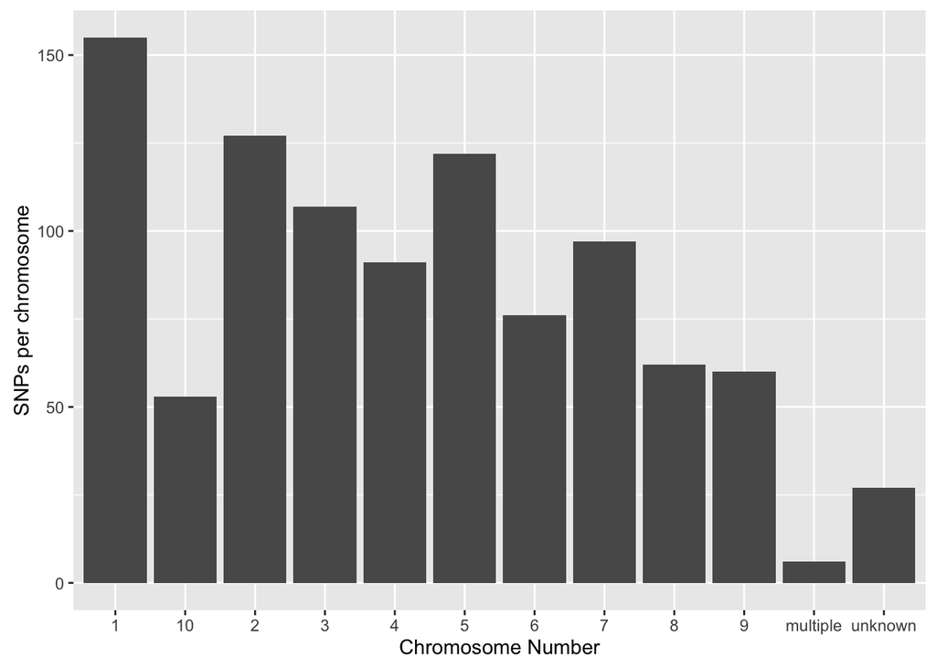

```r
library(ggplot2)
total_snps_per_chromosome <- ggplot(data = tidy_snp, aes(x = Chromosome)) + geom_bar() + ylab("SNPs per chromosome") + xlab("Chromosome Number")

print(total_snps_per_chromosome)
```

- It seems that the most SNPs map to chromosome 1 between both maize and teosinte.
- Plot Missing data and amount of heterozygosity

```r
homo_het <- function(x){
  if(x == "?/?")
    return("NA")
  else if (x == "G/G" | x == "A/A" | x == "C/C" | x == "T/T")
    return("homo")
  else
    return("het")
}
tidy_fang$homo_het <- as.character(lapply(tidy_fang$value, FUN = homo_het))
tidy_fang
```

[output not shown]

[output cut: 19986 more lines]

```r
ZMMIL <- tidy_fang$homo_het[tidy_fang$Group == "ZMMIL"]

ZMMLR <- tidy_fang$homo_het[tidy_fang$Group == "ZMMLR"]

ZMMMR <- tidy_fang$homo_het[tidy_fang$Group == "ZMMMR"]

ZMPBA <- tidy_fang$homo_het[tidy_fang$Group == "ZMPBA"]

ZMPIL <- tidy_fang$homo_het[tidy_fang$Group == "ZMPIL"]

ZMPJA <- tidy_fang$homo_het[tidy_fang$Group == "ZMPJA"]


ZMMIL <- c(sum(c(ZMMIL == "homo")),sum(c(ZMMIL == "het")),sum(c(ZMMIL == "NA")))

ZMMLR <-c(sum(c(ZMMLR == "homo")), sum(c(ZMMLR == "het")), sum(c(ZMMLR == "NA")))

ZMMMR <- c(sum(c(ZMMMR == "homo")), sum(c(ZMMMR == "het")), sum(c(ZMMMR == "NA")))

ZMPBA <- c(sum(c(ZMPBA == "homo")), sum(c(ZMPBA == "het")), sum(c(ZMPBA == "NA")))

ZMPIL <- c(sum(c(ZMPIL == "homo")),sum(c(ZMPIL == "het")),sum(c(ZMPIL == "NA")))

ZMPJA <- c(sum(c(ZMPJA == "homo")), sum(c(ZMPJA == "het")), sum(c(ZMPJA == "NA")))

het_data.frame <- data.frame(cbind(ZMMIL, ZMMLR, ZMMMR, ZMPBA, ZMPIL, ZMPJA))
grps <- c("ZMMIL", "ZMMLR", "ZMMMR", "ZMPBA","ZMPIL", "ZMPJA")
het_df.melt <- melt(het_data.frame)
het_df.melt$type <- c("homo", "het", "NA")
het_df.melt
```

```
##    variable  value type
## 1     ZMMIL 259176 homo
## 2     ZMMIL   1017  het
## 3     ZMMIL  24877   NA
## 4     ZMMLR 981471 homo
## 5     ZMMLR 206037  het
## 6     ZMMLR  47140   NA
## 7     ZMMMR  22854 homo
## 8     ZMMMR    759  het
## 9     ZMMMR   2928   NA
## 10    ZMPBA 648658 homo
## 11    ZMPBA 195961  het
## 12    ZMPBA  40081   NA
## 13    ZMPIL  37841 homo
## 14    ZMPIL    731  het
## 15    ZMPIL   1731   NA
## 16    ZMPJA  27393 homo
## 17    ZMPJA   5394  het
## 18    ZMPJA    635   NA
```

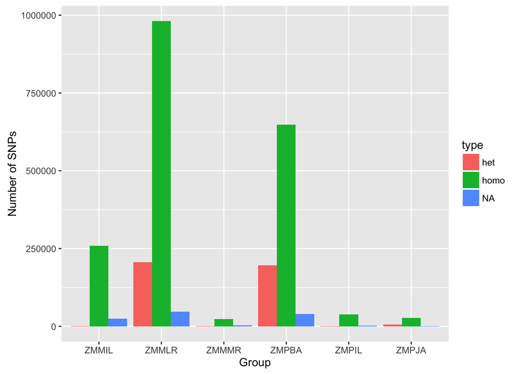

```r
ggplot(data = het_df.melt, aes(x = variable, y = value, fill = type)) + geom_bar(stat = "identity", position= "dodge") + xlab("Group") + ylab("Number of SNPs")
```